# Лабораторная 7. ARIMA

## 1. ACF белого шума разной длины

Границы значимости примерно $\pm 1.96/\sqrt{T}$. При $T=36$ они широкие, при $T=1000$ узкие. Сами выборочные корреляции — разные конечные выборки, поэтому картинки не совпадают, хотя процесс один. Все три графика совместимы с белым шумом: корреляции жмутся к нулю, доля выбросов за границы близка к 5%. На коротком ряде один-два лага за границей ещё ничего не доказывают. На длинном ряде границы ближе к нулю, поэтому мелкий шум оценки чаще их касается.

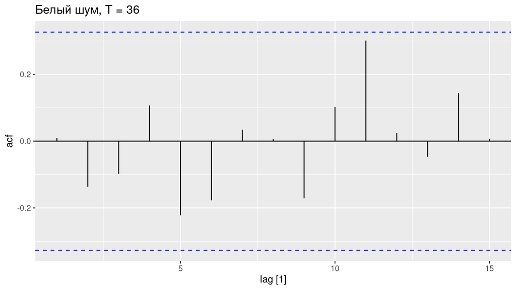

```r
set.seed(1)
wn <- function(n) {
  tsibble(t = seq_len(n), y = rnorm(n), index = t) |>
    ACF(y) |>
    autoplot() +
    labs(title = paste("Белый шум, T =", n))
}
wn(36)
```

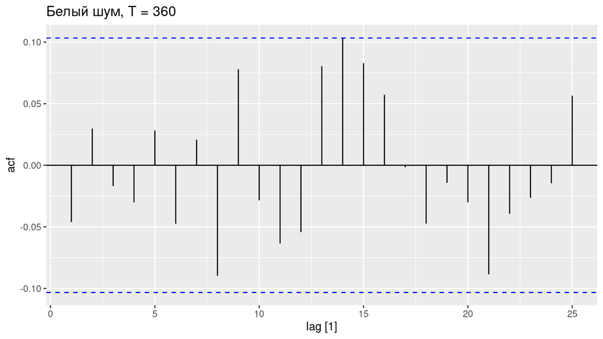

```r
wn(360)
```

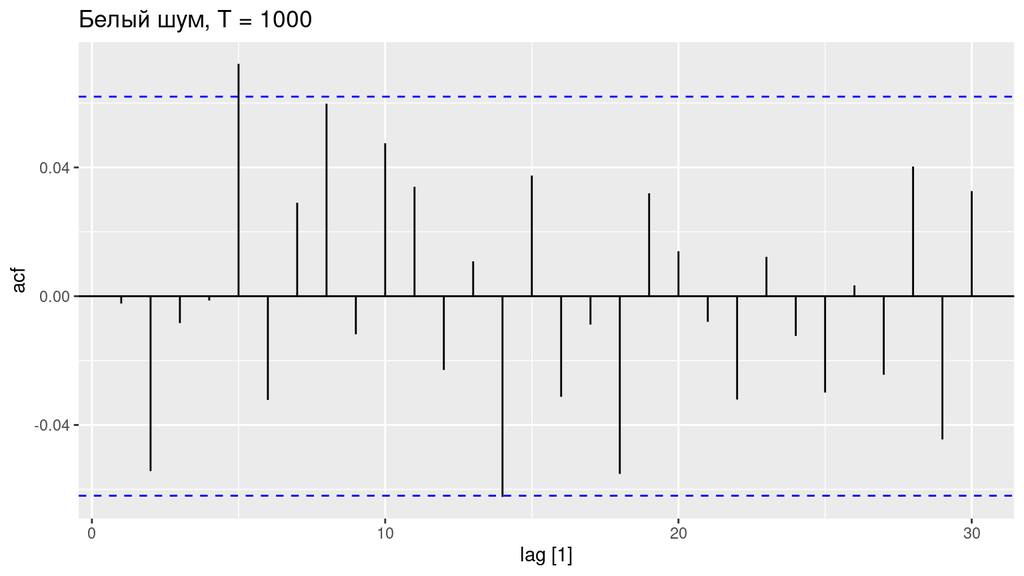

```r
wn(1000)
```

## 2. Amazon

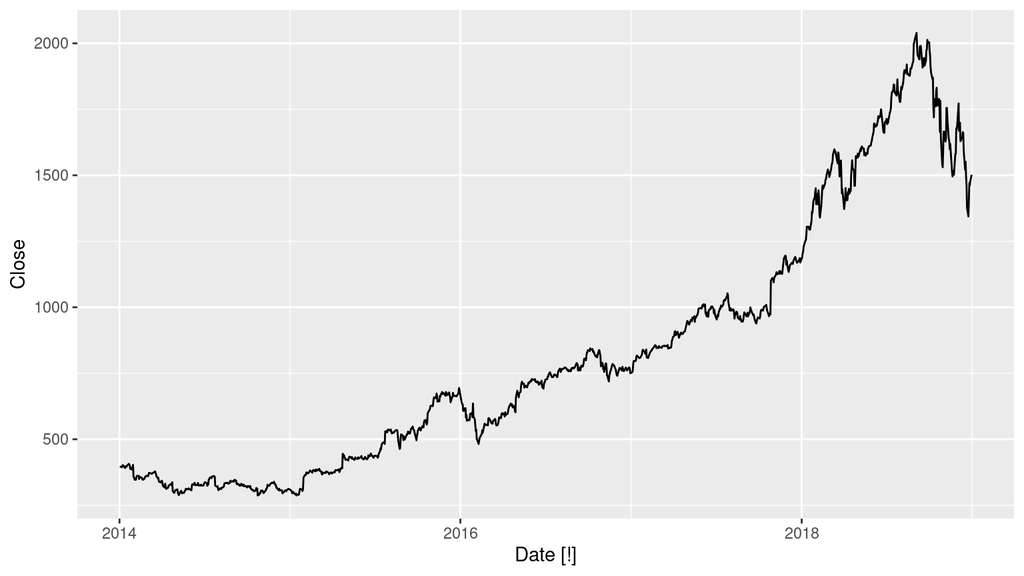

```r
amzn <- gafa_stock |> filter(Symbol == "AMZN")
autoplot(amzn, Close)
```

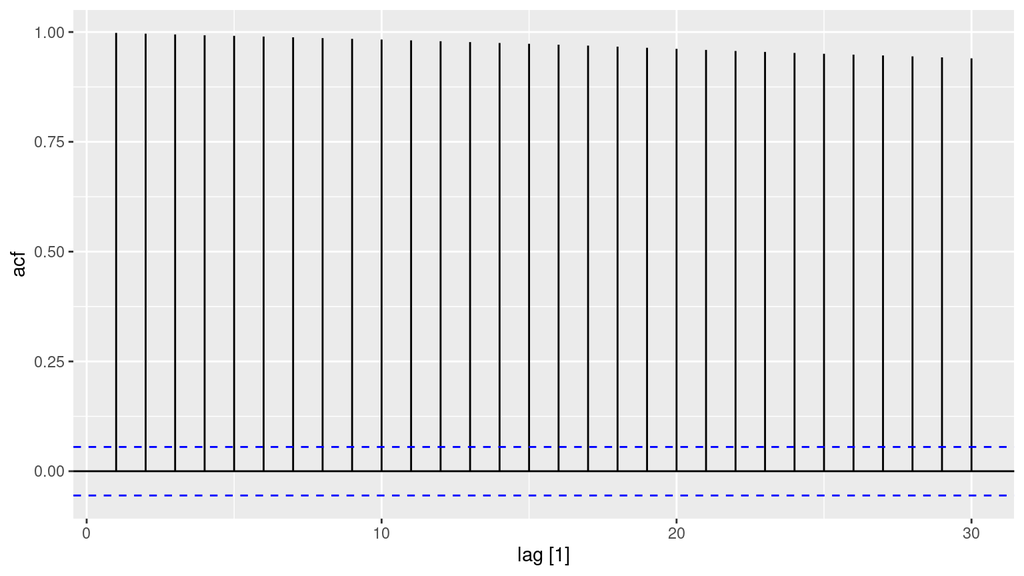

```r
amzn |> ACF(Close) |> autoplot()
```

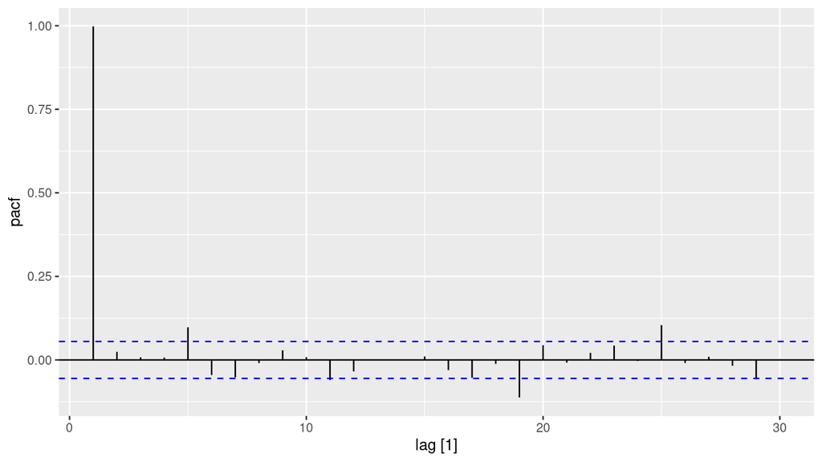

```r
amzn |> PACF(Close) |> autoplot()
```

Цена блуждает, ACF затухает очень медленно, PACF даёт большой первый лаг. Так выглядит ряд с единичным корнем. Нужна разность, иначе ARMA на уровнях будет с коэффициентом около 1 и бесполезными интервалами.

## 3. Преобразование и разности

```r
stationarise <- function(data, y, name) {
  y <- enquo(y)
  lam <- data |> features(!!y, guerrero) |> pull(lambda_guerrero)
  transformed <- data |> mutate(z = box_cox(!!y, lam))
  nd <- transformed |> features(z, unitroot_ndiffs) |> pull(ndiffs)
  ns <- transformed |> features(z, unitroot_nsdiffs) |> pull(nsdiffs)
  cat(name, " lambda =", round(lam, 3), " nsdiffs =", ns, " ndiffs =", nd, "\n")
  out <- transformed
  if (ns > 0) out <- out |> mutate(z = difference(z, lag = 12))
  # квартал и год обработаем ниже отдельно, если период не 12
  if (nd > 0) out <- out |> mutate(z = difference(z, lag = 1))
  print(autoplot(out, z))
  print(out |> ACF(z) |> autoplot())
  invisible(list(lambda = lam, ns = ns, nd = nd))
}
```

Турецкий ВВП — год, сезонной разности нет:

```r
turkey <- global_economy |> filter(Country == "Turkey") |> select(GDP)
lam_tr <- turkey |> features(GDP, guerrero) |> pull(lambda_guerrero)
tr <- turkey |> mutate(z = box_cox(GDP, lam_tr))
c(lambda = lam_tr,
  ndiffs = tr |> features(z, unitroot_ndiffs) |> pull(ndiffs))
```

```
##    lambda    ndiffs
## 0.1572187 1.0000000
```

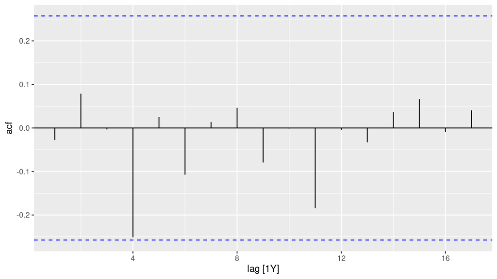

```r
tr |> mutate(z = difference(z)) |> ACF(z) |> autoplot()
```

Размещение в Тасмании — квартал:

```r
tas <- aus_accommodation |>
  filter(State == "Tasmania") |>
  select(Takings)
lam_tas <- tas |> features(Takings, guerrero) |> pull(lambda_guerrero)
tas_z <- tas |> mutate(z = box_cox(Takings, lam_tas))
c(lambda = lam_tas,
  nsdiffs = tas_z |> features(z, unitroot_nsdiffs) |> pull(nsdiffs),
  ndiffs = tas_z |> features(z, unitroot_ndiffs) |> pull(ndiffs))
```

```
##      lambda     nsdiffs      ndiffs
## 0.001819643 1.000000000 1.000000000
```

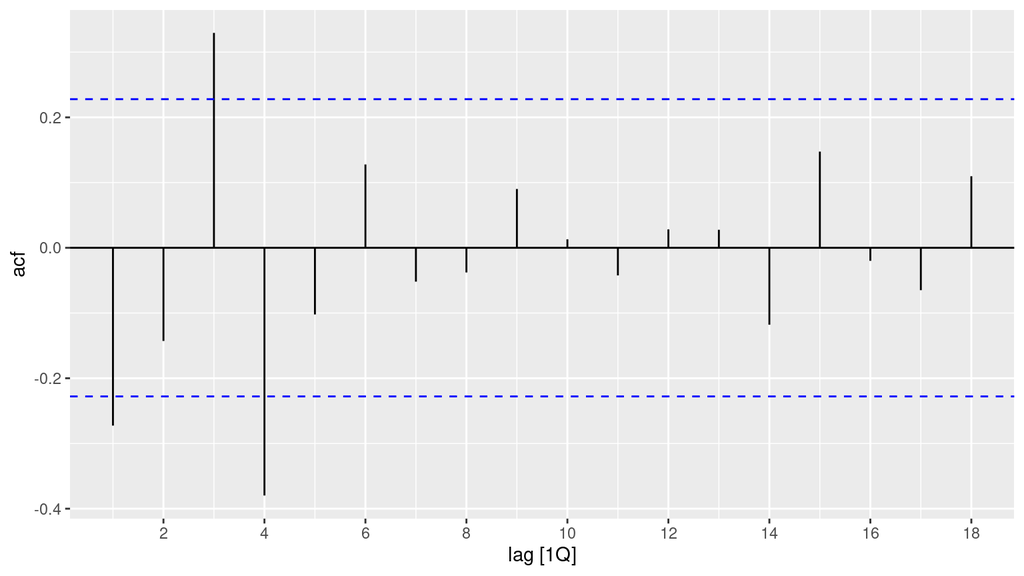

```r
tas_z |>
  mutate(z = difference(z, lag = 4) |> difference()) |>
  ACF(z) |>
  autoplot()
```

Сувениры — месяц. Обычно нужны логарифм, сезонная разность и обычная разность:

```r
lam_s <- souvenirs |> features(Sales, guerrero) |> pull(lambda_guerrero)
souv <- souvenirs |> mutate(z = box_cox(Sales, lam_s))
c(lambda = lam_s,
  nsdiffs = souv |> features(z, unitroot_nsdiffs) |> pull(nsdiffs),
  ndiffs = souv |> features(z, unitroot_ndiffs) |> pull(ndiffs))
```

```
##      lambda     nsdiffs      ndiffs
## 0.002118221 1.000000000 1.000000000
```

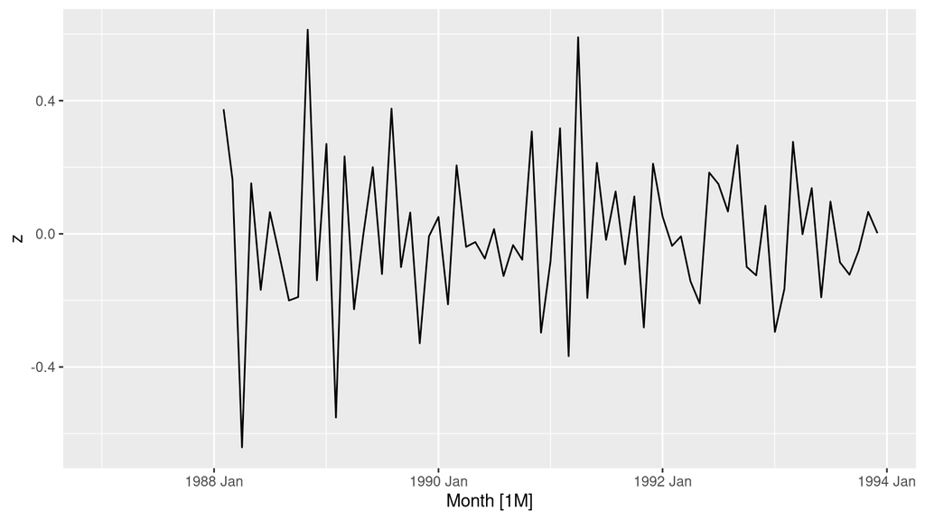

```r
souv_diff <- souv |>
  mutate(z = difference(difference(z, 12)))
autoplot(souv_diff, z)
```

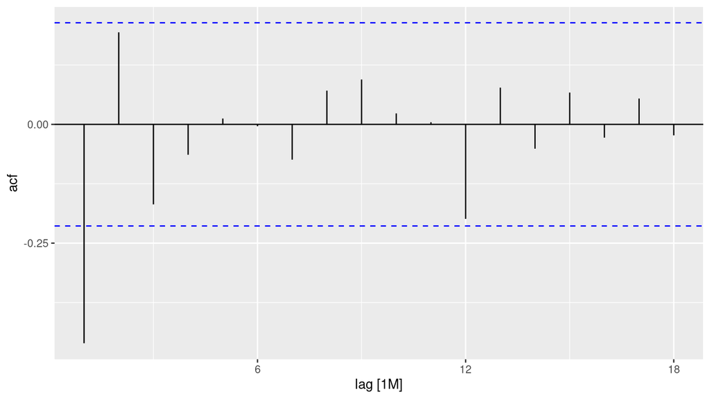

```r
souv_diff |> ACF(z) |> autoplot()
```

## 4. Сувениры в операторах сдвига

Для логарифма продаж (λ близка к 0, беру $\log$) сезонная и первая разности:

$$(1-B)(1-B^{12})\log y_t = \varepsilon_t$$

если тесты просят обе разности. Это ARIMA(0,1,0)(0,1,0)$_{12}$ без константы. Если обычная разность после сезонной уже не нужна, остаётся $(1-B^{12})\log y_t$.

## 5. Розничный ряд

```r
lam_r <- myseries |> features(Turnover, guerrero) |> pull(lambda_guerrero)
ret <- myseries |> mutate(z = box_cox(Turnover, lam_r))
c(lambda = lam_r,
  nsdiffs = ret |> features(z, unitroot_nsdiffs) |> pull(nsdiffs),
  ndiffs = ret |> features(z, unitroot_ndiffs) |> pull(ndiffs))
```

```
##    lambda   nsdiffs    ndiffs
## 0.1895908 0.0000000 1.0000000
```

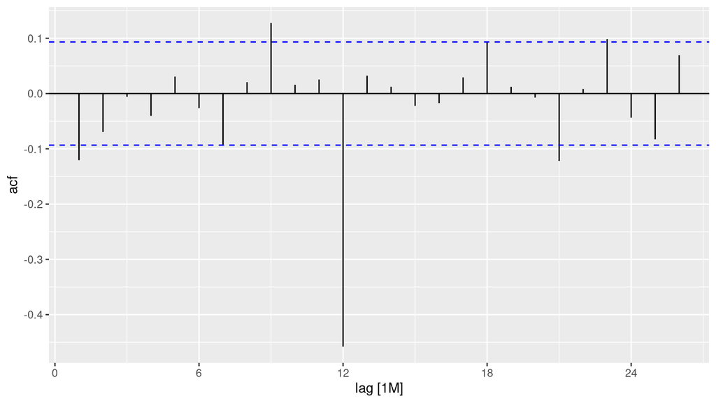

```r
ret |>
  mutate(z = difference(difference(z, 12))) |>
  ACF(z) |>
  autoplot()
```

## 6. Имитация

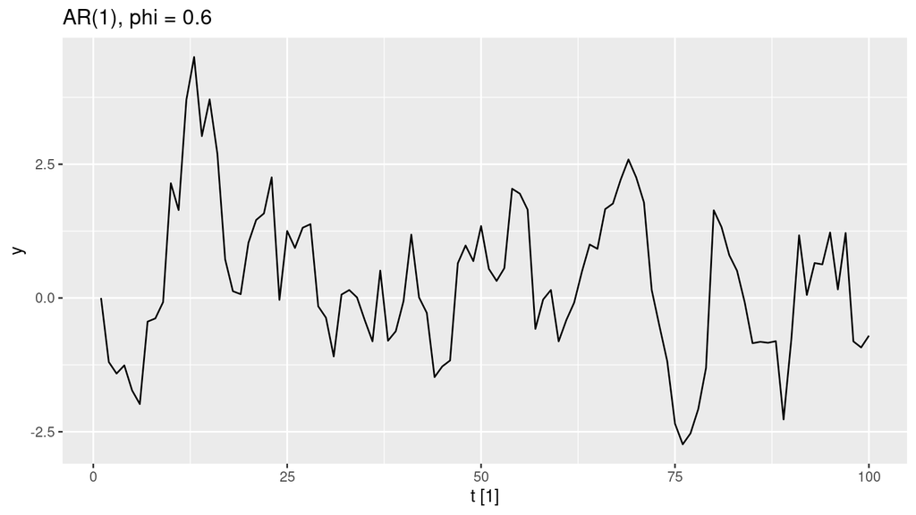

```r
sim_ar1 <- function(phi, n = 100, sigma = 1) {
  e <- rnorm(n, sd = sigma)
  y <- numeric(n)
  for (t in 2:n) y[t] <- phi * y[t - 1] + e[t]
  tsibble(t = seq_len(n), y = y, index = t)
}
set.seed(7)
autoplot(sim_ar1(0.6), y) + labs(title = "AR(1), phi = 0.6")
```

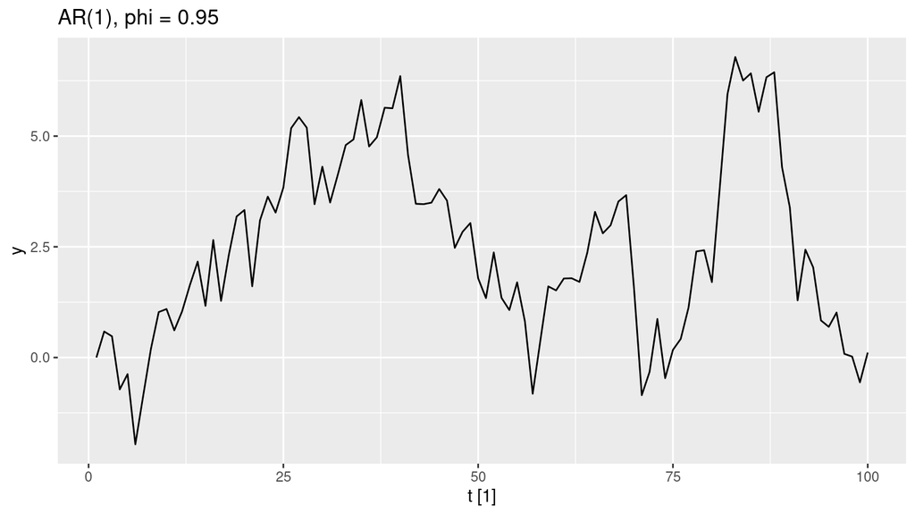

```r
autoplot(sim_ar1(0.95), y) + labs(title = "AR(1), phi = 0.95")
```

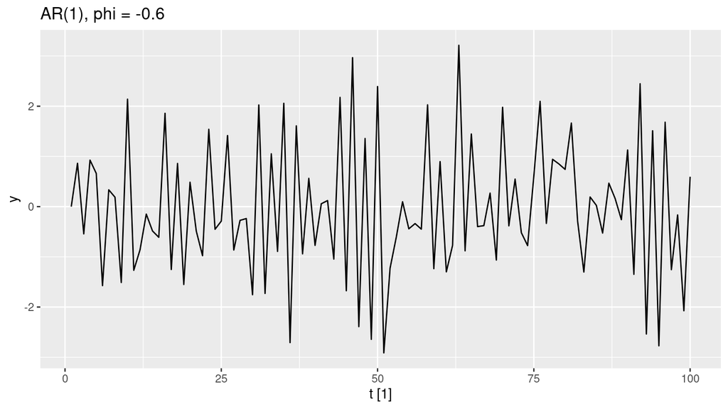

```r
autoplot(sim_ar1(-0.6), y) + labs(title = "AR(1), phi = -0.6")
```

Чем ближе $\phi_1$ к 1, тем длиннее память и тем больше ряд гуляет. Отрицательный коэффициент даёт пилу.

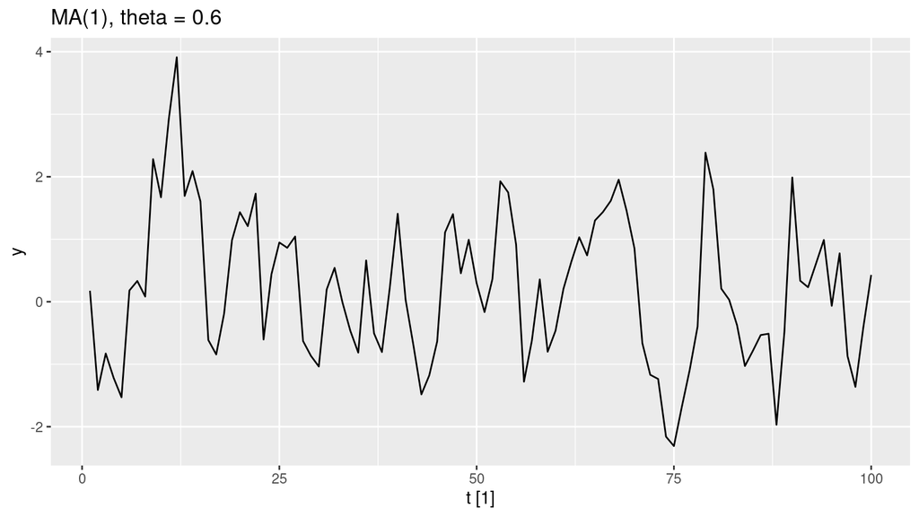

```r
sim_ma1 <- function(theta, n = 100, sigma = 1) {
  e <- rnorm(n + 1, sd = sigma)
  y <- e[-1] + theta * e[-(n + 1)]
  tsibble(t = seq_len(n), y = y, index = t)
}
set.seed(7)
autoplot(sim_ma1(0.6), y) + labs(title = "MA(1), theta = 0.6")
```

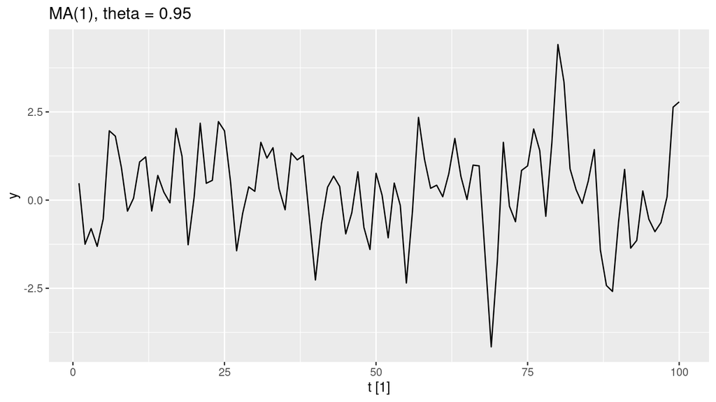

```r
autoplot(sim_ma1(0.95), y) + labs(title = "MA(1), theta = 0.95")
```

MA(1) остаётся короткой памятью при любом $\theta$. Меняется только сила соседнего выброса.

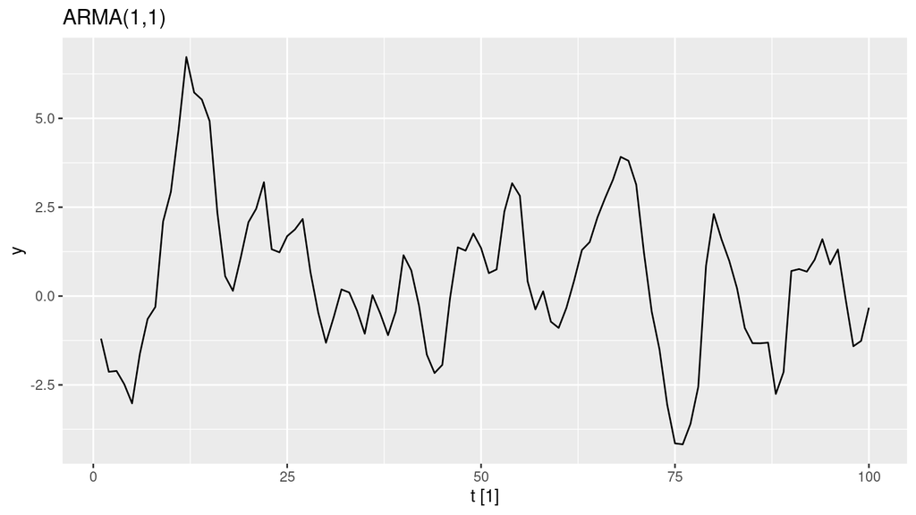

```r
sim_arma <- function(phi, theta, n = 100) {
  e <- rnorm(n + 1)
  y <- numeric(n)
  y[1] <- e[2]
  for (t in 2:n) y[t] <- phi * y[t - 1] + e[t + 1] + theta * e[t]
  tsibble(t = seq_len(n), y = y, index = t)
}
sim_ar2 <- function(phi1, phi2, n = 100) {
  e <- rnorm(n)
  y <- numeric(n)
  for (t in 3:n) y[t] <- phi1 * y[t - 1] + phi2 * y[t - 2] + e[t]
  tsibble(t = seq_len(n), y = y, index = t)
}
set.seed(7)
autoplot(sim_arma(0.6, 0.6), y) + labs(title = "ARMA(1,1)")
```

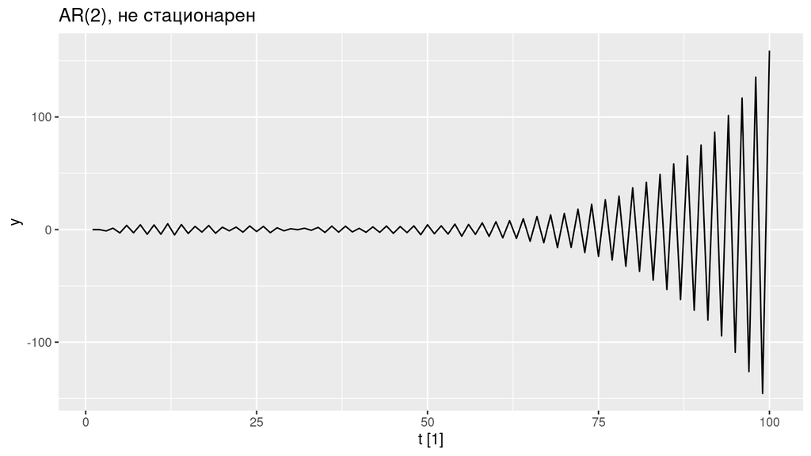

```r
autoplot(sim_ar2(-0.8, 0.3), y) + labs(title = "AR(2), не стационарен")
```

## 7. Авиапассажиры Австралии

```r
fit_air <- aus_airpassengers |>
  model(
    auto = ARIMA(Passengers),
    arima010 = ARIMA(Passengers ~ 1 + pdq(0, 1, 0)),
    arima212 = ARIMA(Passengers ~ 1 + pdq(2, 1, 2)),
    arima212_noc = ARIMA(Passengers ~ 0 + pdq(2, 1, 2)),
    arima021 = ARIMA(Passengers ~ 1 + pdq(0, 2, 1))
  )
glance(fit_air) |> select(.model, AIC, AICc, BIC)
```

[output not shown]

```r
report(fit_air |> select(auto))
```

```
## Series: Passengers
## Model: ARIMA(0,2,1)
##
## Coefficients:
##           ma1
##       -0.8963
## s.e.   0.0594
##
## sigma^2 estimated as 4.308:  log likelihood=-97.02
## AIC=198.04   AICc=198.32   BIC=201.65
```

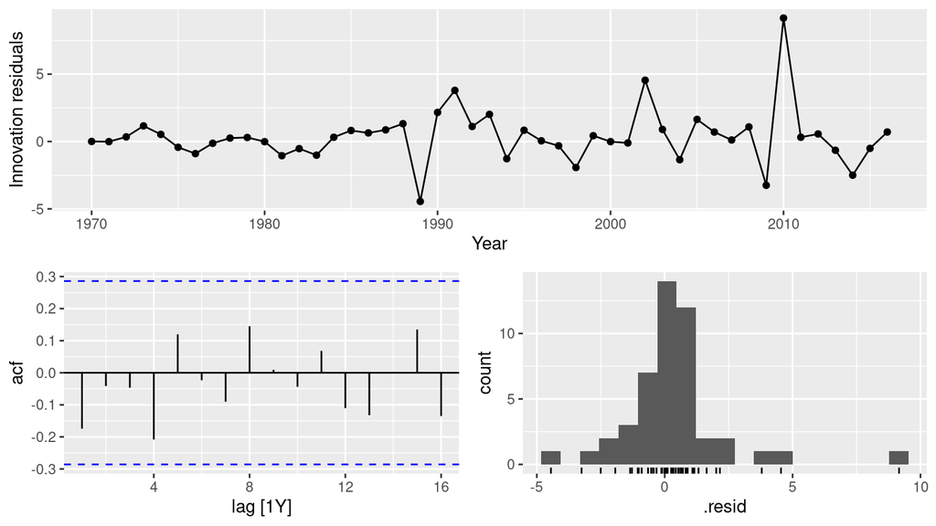

```r
gg_tsresiduals(fit_air |> select(auto))
```

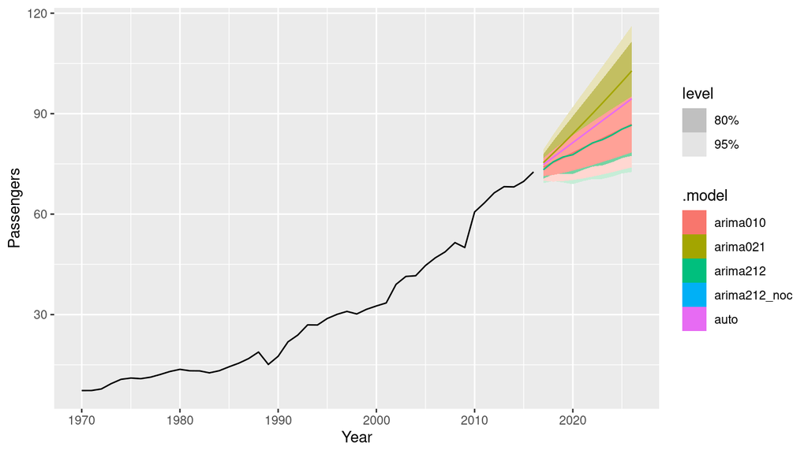

```r
autoplot(forecast(fit_air, h = 10), aus_airpassengers)
```

`ARIMA()` выбирает порядок по AICc; остатки этой модели должны быть близки к белому шуму. В операторах выбранная модель читается из `report`: для ARIMA(p,d,q) с константой это $(1-\phi(B))(1-B)^d y_t = c + (1+\theta(B))\varepsilon_t$.

ARIMA(0,1,0) с дрейфом — случайное блуждание с наклоном, прогноз прямая. ARIMA(2,1,2) с дрейфом гнёт эту прямую короткой памятью. Без константы наклон пропадает, прогноз выходит на горизонталь. ARIMA(0,2,1) с константой даёт квадратичный тренд: константа при второй разности — это прирост наклона. На десяти годах парабола уже неправдоподобна.

## 8. ВВП США

```r
us <- global_economy |> filter(Country == "United States") |> select(GDP)
lam_us <- us |> features(GDP, guerrero) |> pull(lambda_guerrero)
us_fit <- us |>
  model(
    auto = ARIMA(box_cox(GDP, lam_us)),
    arima210 = ARIMA(box_cox(GDP, lam_us) ~ pdq(2, 1, 0)),
    arima011 = ARIMA(box_cox(GDP, lam_us) ~ 1 + pdq(0, 1, 1)),
    ets = ETS(GDP)
  )
glance(us_fit) |> select(.model, AIC, AICc)
```

```
## # A tibble: 4 × 3
##   .model     AIC  AICc
##   <chr>    <dbl> <dbl>
## 1 auto      657.  657.
## 2 arima210  659.  659.
## 3 arima011  659.  659.
## 4 ets      3191. 3192.
```

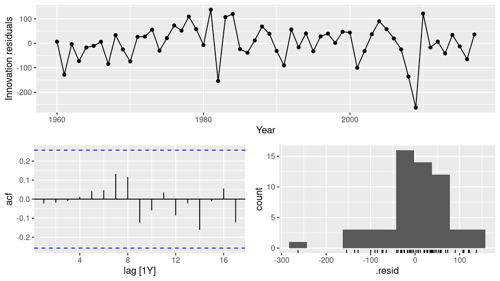

```r
gg_tsresiduals(us_fit |> select(auto))
```

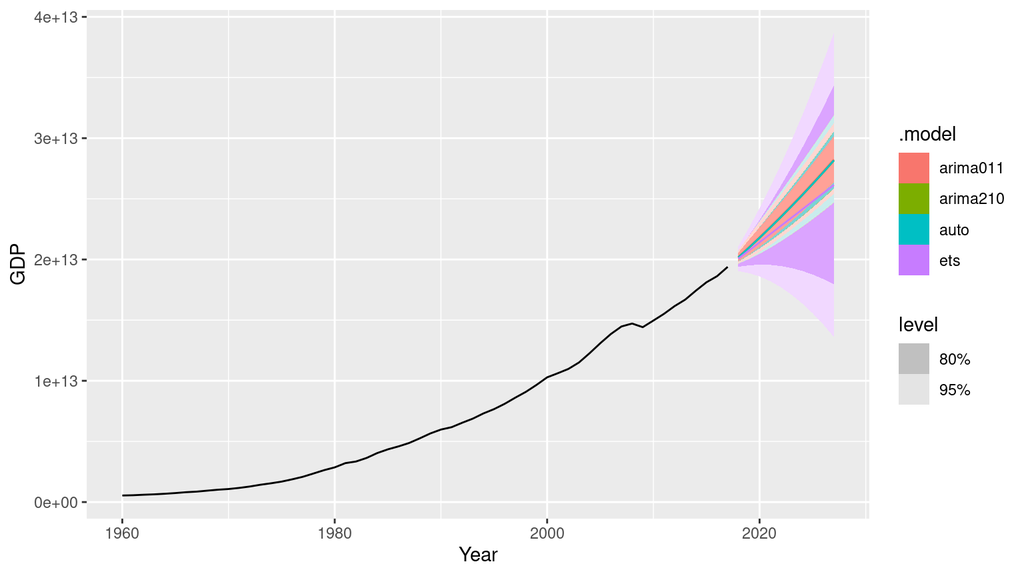

```r
autoplot(forecast(us_fit, h = 10), us)
```

Лучший по AICc среди ARIMA оставляю, если остатки без структуры. ETS без преобразования тоже растёт, но интервалы и форма тренда другие: ETS не разностный. На таком гладком ряде оба прогноза разумны и близки на 5–10 лет.

## 9. Прибытия из Японии

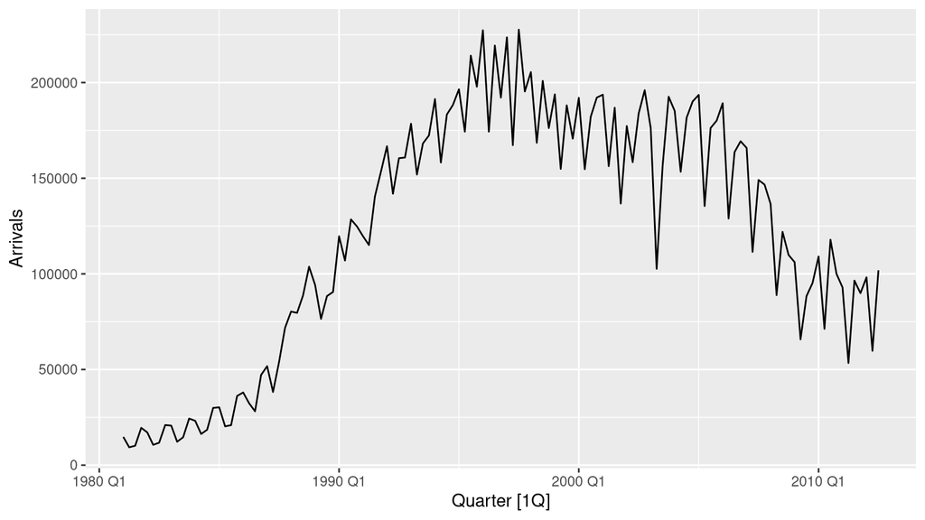

```r
japan <- aus_arrivals |> filter(Origin == "Japan")
autoplot(japan, Arrivals)
```

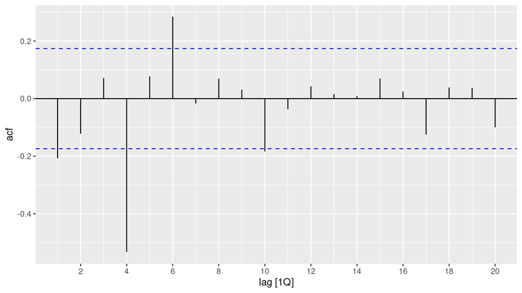

```r
japan |>
  mutate(d = difference(difference(Arrivals, 4))) |>
  ACF(d) |>
  autoplot()
```

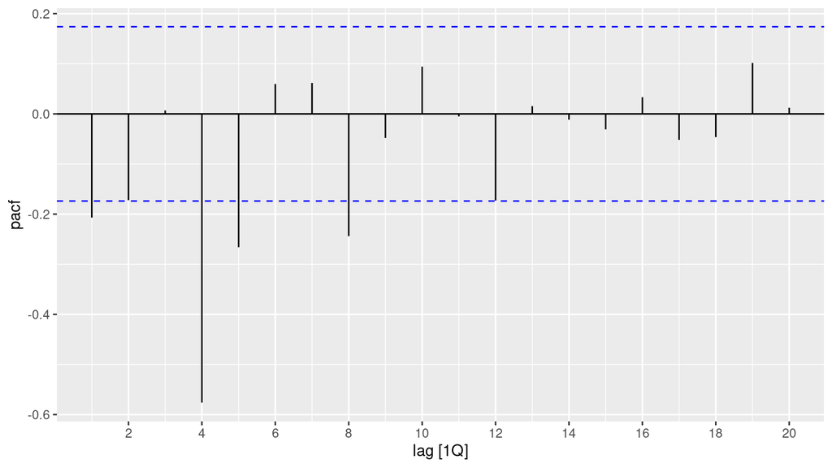

```r
japan |>
  mutate(d = difference(difference(Arrivals, 4))) |>
  PACF(d) |>
  autoplot()
```

```r
fit_j <- japan |>
  model(
    chosen = ARIMA(Arrivals ~ pdq(1, 1, 1) + PDQ(0, 1, 1)),
    auto = ARIMA(Arrivals)
  )
glance(fit_j)
```

```
## # A tibble: 2 × 9
##   Origin .model     sigma2 log_lik   AIC  AICc   BIC ar_roots  ma_roots
##   <chr>  <chr>       <dbl>   <dbl> <dbl> <dbl> <dbl> <list>    <list>
## 1 Japan  chosen 175646364.  -1331. 2670. 2670. 2681. <cpl [1]> <cpl [5]>
## 2 Japan  auto   174801727.  -1331. 2669. 2670. 2681. <cpl [4]> <cpl [5]>
```

```r
report(fit_j)
```

```
## # A tibble: 2 × 9
##   Origin .model     sigma2 log_lik   AIC  AICc   BIC ar_roots  ma_roots
##   <chr>  <chr>       <dbl>   <dbl> <dbl> <dbl> <dbl> <list>    <list>
## 1 Japan  chosen 175646364.  -1331. 2670. 2670. 2681. <cpl [1]> <cpl [5]>
## 2 Japan  auto   174801727.  -1331. 2669. 2670. 2681. <cpl [4]> <cpl [5]>
```

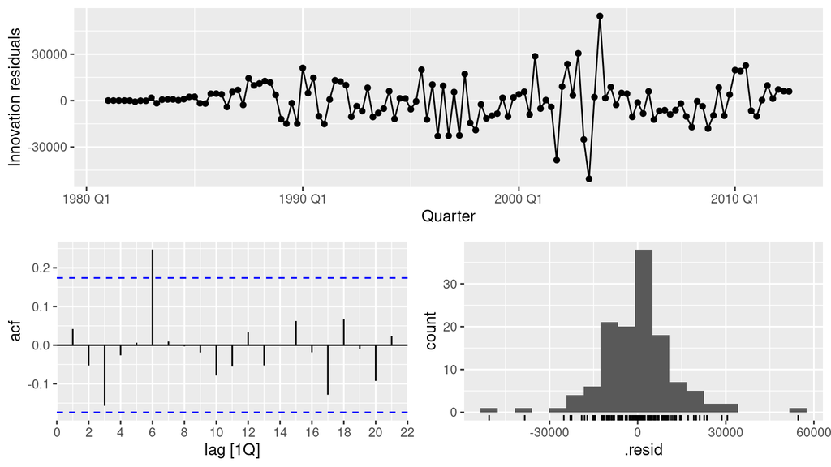

```r
gg_tsresiduals(fit_j |> select(auto))
```

После сезонной и обычной разности ACF обрывается на коротких лагах и на лаге 4, PACF затухает. Это похоже на сезонную MA плюс короткую AR/MA, то есть что-то вроде ARIMA(1,1,1)(0,1,1)$_4$. Если `ARIMA()` выбирает другой порядок, сравниваю AICc и остатки и оставляю модель с меньшим AICc и остатками без сезонного пика.

Запись авто-модели беру из `report`. Без оператора сдвига для ARIMA(1,1,1)(0,1,1)$_4$:

$$(1-\phi_1 B)(1-B)(1-B^4) y_t = (1+\theta_1 B)(1+\Theta_1 B^4)\varepsilon_t.$$

## 10. Занятость, розничная торговля США

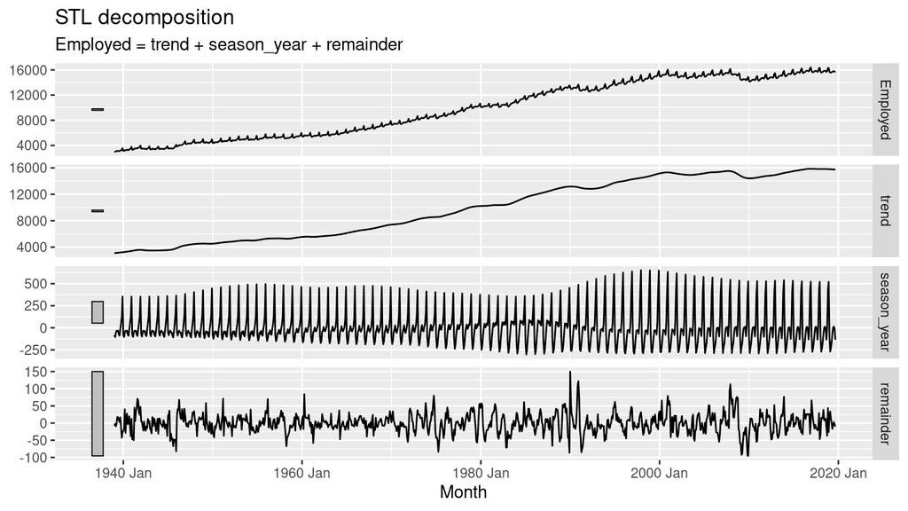

```r
retail_us <- us_employment |> filter(Title == "Retail Trade")
dcmp <- retail_us |> model(STL(Employed))
components(dcmp) |> autoplot()
```

```r
lam_e <- retail_us |> features(Employed, guerrero) |> pull(lambda_guerrero)
c(lambda = lam_e,
  ns = retail_us |>
    mutate(z = box_cox(Employed, lam_e)) |>
    features(z, unitroot_nsdiffs) |> pull(nsdiffs),
  nd = retail_us |>
    mutate(z = box_cox(Employed, lam_e)) |>
    features(z, unitroot_ndiffs) |> pull(ndiffs))
```

```
##    lambda        ns        nd
## 0.5479707 1.0000000 1.0000000
```

```r
fit_e <- retail_us |>
  model(
    a = ARIMA(box_cox(Employed, lam_e)),
    b = ARIMA(box_cox(Employed, lam_e) ~ pdq(2, 1, 0) + PDQ(0, 1, 1)),
    c = ARIMA(box_cox(Employed, lam_e) ~ pdq(0, 1, 1) + PDQ(0, 1, 1))
  )
glance(fit_e) |> select(.model, AICc) |> arrange(AICc)
```

```
## # A tibble: 3 × 2
##   .model  AICc
##   <chr>  <dbl>
## 1 a      1861.
## 2 b      1900.
## 3 c      1941.
```

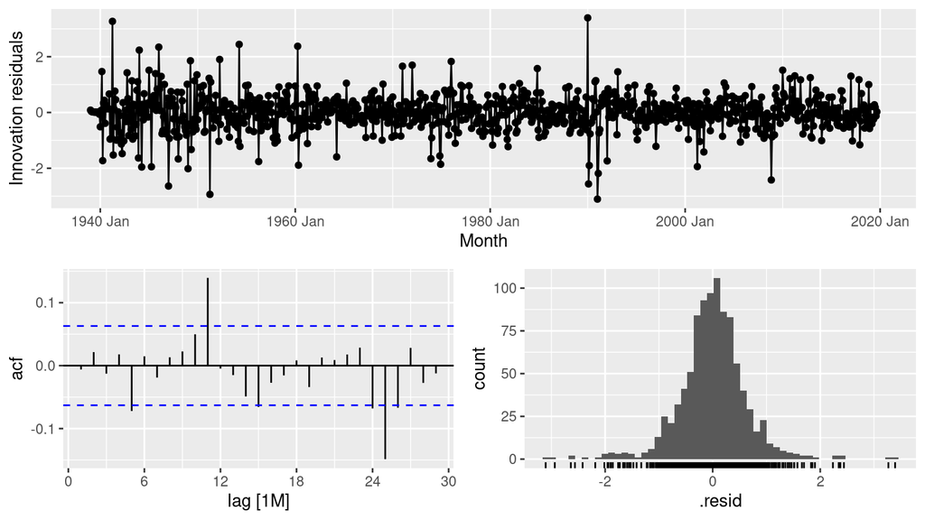

```r
best_e <- glance(fit_e) |> slice_min(AICc, n = 1) |> pull(.model)
gg_tsresiduals(fit_e |> select(all_of(best_e)))
```

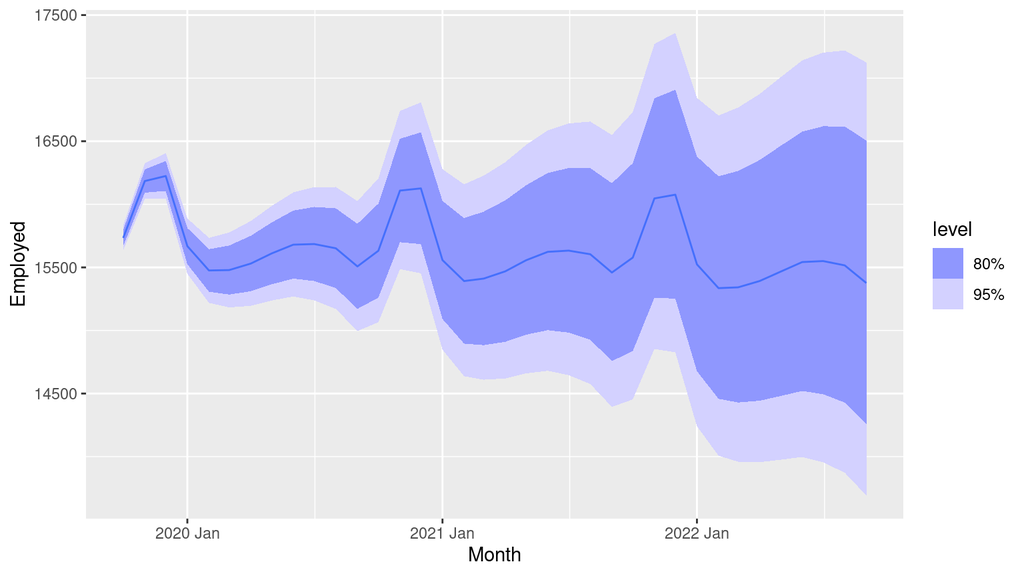

```r
fc_e <- forecast(fit_e |> select(all_of(best_e)), h = 36)
autoplot(fc_e)
```

```r
fc_e |> hilo(level = 95) |> slice_tail(n = 3)
```

```
## # A tsibble: 3 x 5 [1M]
## # Key:       .model [1]
##   .model    Month       Employed  .mean                  `95%`
##   <chr>     <mth>         <dist>  <dbl>                 <hilo>
## 1 a      2022 Jul t(N(360, 112)) 15550. [13954.60, 17202.43]95
## 2 a      2022 Aug t(N(359, 119)) 15516. [13872.95, 17219.36]95
## 3 a      2022 Sep t(N(357, 126)) 15376. [13691.90, 17124.25]95
```

Свежий ряд с FRED в этот прогон не подгружался. Хвост `us_employment` — это фактические значения внутри пакета; отдельной сверки с сегодняшним релизом нет.

## 11. Электричество Австралии

Ряд квартальный, 24 месяца — это 8 кварталов.

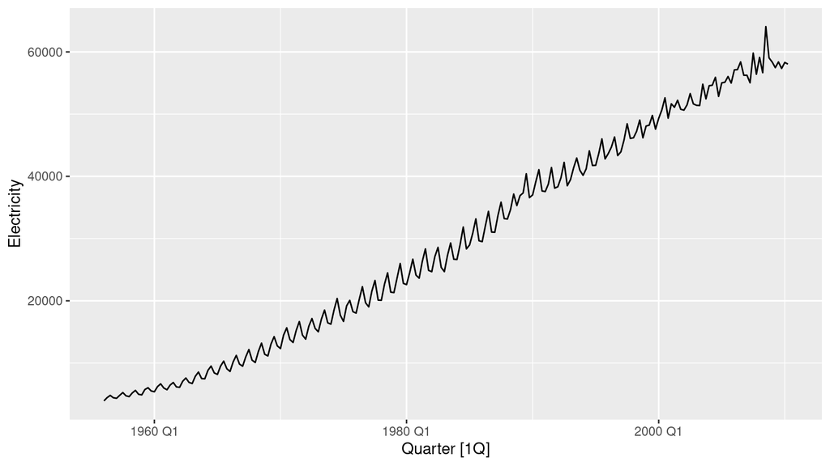

```r
elec <- aus_production |> select(Electricity)
autoplot(elec, Electricity)
```

```r
lam_el <- elec |> features(Electricity, guerrero) |> pull(lambda_guerrero)
c(lambda = lam_el,
  ns = elec |> mutate(z = box_cox(Electricity, lam_el)) |>
    features(z, unitroot_nsdiffs) |> pull(nsdiffs),
  nd = elec |> mutate(z = box_cox(Electricity, lam_el)) |>
    features(z, unitroot_ndiffs) |> pull(ndiffs))
```

```
##    lambda        ns        nd
## 0.5195182 1.0000000 1.0000000
```

```r
fit_el <- elec |>
  model(
    a = ARIMA(box_cox(Electricity, lam_el)),
    b = ARIMA(box_cox(Electricity, lam_el) ~ pdq(1, 1, 1) + PDQ(0, 1, 1)),
    c = ARIMA(box_cox(Electricity, lam_el) ~ pdq(0, 1, 2) + PDQ(1, 1, 0)),
    ets = ETS(Electricity)
  )
glance(fit_el) |> select(.model, AIC, AICc) |> arrange(AICc)
```

```
## # A tibble: 4 × 3
##   .model   AIC  AICc
##   <chr>  <dbl> <dbl>
## 1 b      1232. 1232.
## 2 a      1232. 1233.
## 3 c      1272. 1272.
## 4 ets    3841. 3841.
```

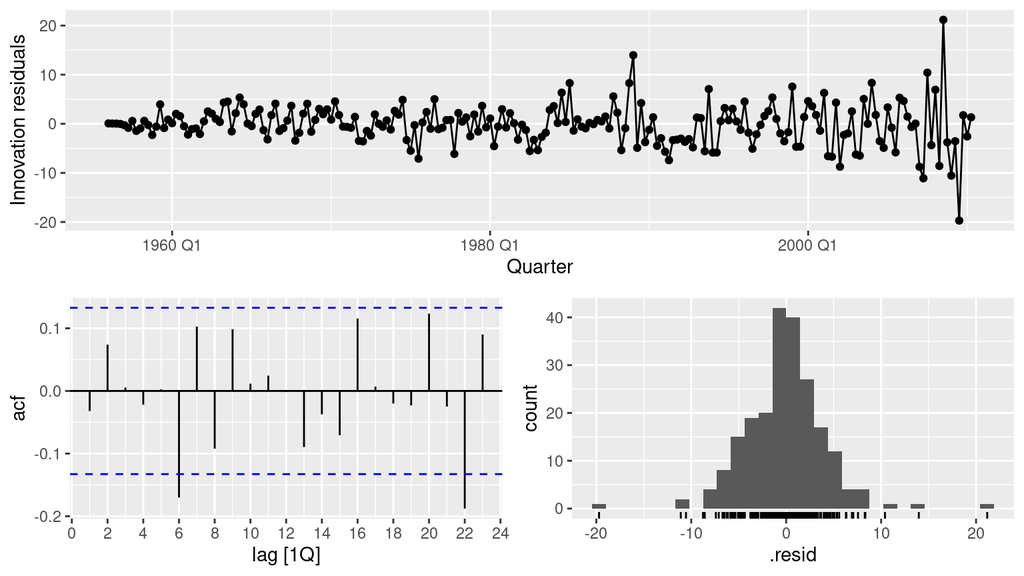

```r
best_el <- glance(fit_el) |>
  filter(.model != "ets") |>
  slice_min(AICc, n = 1) |>
  pull(.model)
gg_tsresiduals(fit_el |> select(all_of(best_el)))
```

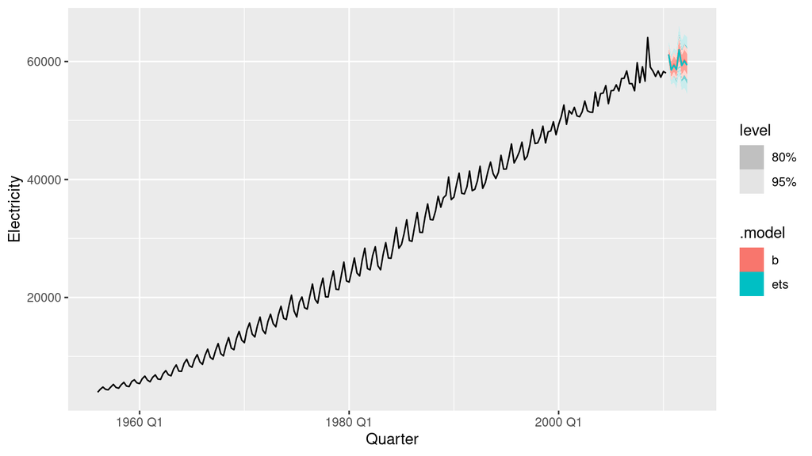

```r
autoplot(forecast(fit_el |> select(all_of(best_el), ets), h = 8), elec)
```